# Do California Students at Charter Schools Score Better on the SAT and ACT?

## by Eric Gordon

**This Analysis is jsut a portion of the entire investigation into this data. To read or access files from this full investigation, click [here](https://github.com/ericgordo/P4_EDA_CA_Schools)**

This analysis compares schools across the state of California. Specifically, it looks at the percent of students who score above the national average on the SAT and ACT standardized tests. The average score of the SAT is a 1500, and the average score on the ACT test is 21.

## Percent of Students who Score Above Average on Each Test

Each point on the chart below represents a school. The X axis position of each point represents the percent of students at the school who scored above average on the ACT, while the Y axis position represents the percent of students scoring above average on the SAT. Thus the schools in the top right corner have more students who score above average on both tests, while the bottom left corner represents schools in which the smallest percent of students perform above average on each test. The orange points represent traditional public schools, and the blue dots represent charter schools.

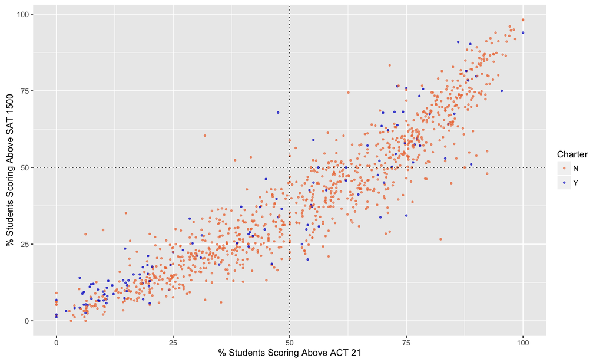

The graph above shows the vast difference between schools in the percent of students performing above average on both tests. However there seems to be a disparity between the charter schools and traditional public schools. Let’s investigate some stats.

## Further Statistics

```
## [1] "Charter Schools on Graph Above"
```

```
##
##   N   Y
## 945 125
```

```
## [1] "SAT Percent Breakdown"
```

```
## $N
##    Min. 1st Qu.  Median    Mean 3rd Qu.    Max.    NA's
##    0.00   21.76   37.98   40.04   57.25   98.20       7
##
## $Y
##    Min. 1st Qu.  Median    Mean 3rd Qu.    Max.    NA's
##    0.00   12.02   29.34   33.33   50.43   93.94       8
```

```
## [1] "ACT Percent Breakdown"
```

```
## $N
##    Min. 1st Qu.  Median    Mean 3rd Qu.    Max.    NA's
##    0.00   32.81   54.79   53.08   75.00  100.00      88
##
## $Y
##    Min. 1st Qu.  Median    Mean 3rd Qu.    Max.    NA's
##    0.00   14.29   34.88   39.61   68.89  100.00      79
```

## Statistical Tests for Significance

*Is there a significant difference in the percentage of students who score above average on these tests in public vs. charter schools?*

$H_o =$ *There is no difference in the percent of students who score above average on this test*

$H_a =$ *There is a difference in the percent of students who score above average on this test*

```r
#"ACT Statistical Difference"
wilcox.test(y1, x1, conf.int=TRUE)
```

```
##
##  Wilcoxon rank sum test with continuity correction
##
## data:  y1 and x1
## W = 75248, p-value = 6.211e-07
## alternative hypothesis: true location shift is not equal to 0
## 95 percent confidence interval:
##   8.390082 18.819980
## sample estimates:
## difference in location
##               13.67994
```

```r
#"SAT Statistical Difference"
wilcox.test(x2, y2, conf.int=TRUE)
```

```
##
##  Wilcoxon rank sum test with continuity correction
##
## data:  x2 and y2
## W = 45864, p-value = 4.808e-05
## alternative hypothesis: true location shift is not equal to 0
## 95 percent confidence interval:
##  -13.439973  -4.769942
## sample estimates:
## difference in location
##              -9.090032
```

The results above show that there is statistically significant difference in the percent of students who score above average in both tests at public schools compared to charter schools. This can be seen in the small p-values from both tests above. The Wilcoxon-Mann-Whitney test was used because none of the distributions were normal.

## Conclusion

It is interesting that for the 2014-2015 school year, there was a statistically significant difference between the number of students who score above average on both the SAT and ACT tests. This may be surprising, or shocking to many, however there may be further questions worth investigating to see why this result may happen. It is possible that other variables in these schools like the size of schools has a large effect on these results. For the scope of this investigation, I will leave this analysis here, and recommend that further investigations look into reasons why this result may have occurred.

# Work Cited

All data used in this analysis found at: http://www.cde.ca.gov/ds/

[figure not shown]